# BUA 455 Lecture 14 - Model Selection Continued

### Animals Data Dictionary - Description of Variables

| Variable | Type | Description |
| --- | --- | --- |
| Species | Nominal | Name of Species |
| TotalSleep | Quantitative | Total Sleep = sum of slow wave and paradoxical sleep (hrs/day) |
| BodyWt | Quantitative | Average Body Weight in kilograms |
| LNBodyWt | Quantitative | Natural Log of Body Weight |
| BrainWt | Quantitative | Average Brain Weight in grams |
| LNBrainWt | Quantitative | Natural Log of Brain Weight |
| LifeSpan | Quantitative | Maximum Life Span in years |
| LNLifeSpan | Quantitative | Natural Log of Life Span |
| Gestation | Quantitative | Gestation Time in days |
| Predation | Ordinal | Predation Index (1 = least likely to be preyed upon, 5 = most likely) |
| Exposure | Ordinal | Sleep Exposure Index (1 = least exposed while sleeping, 5 = most exposed |
| Danger | Ordinal | Overall Danger Index (1 = least danger from other animals, 5 = most most danger |

#### Intuitvely, there is likely to be redundancy between `Predation`, `Exposure`, and `Danger`.

### Matrix of Scatterplots

- Like correlation matrices, scatterplot matrices are a useful way to quickly examine all possible predictors.
- First let’s look at untransformed quantitative variables.
  - Notice BodyWt, BrainWt, LifeSpan plots all show observations clustered in the corner.
  - That indicates that these dsitributions are skewed and should be log transformed.
  - Could be verified with histograms

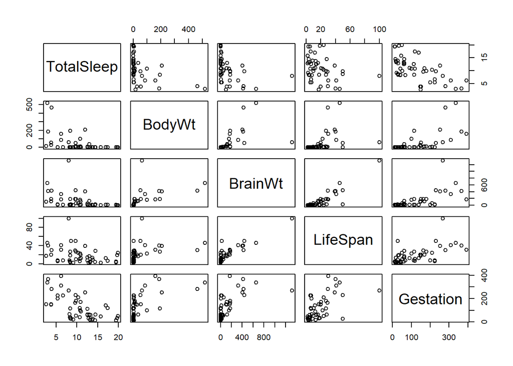

```r
animal_mat1 <- animals |> select(TotalSleep,
                                 BodyWt,
                                 BrainWt,
                                 LifeSpan,
                                 Gestation)

pairs(animal_mat1)
```

### Scatterplot Matrix of Transformed Variables

- Next is same matrix with the LN transformed variables.
- Notice that distributions look better BUT some variables are highly correlated
  - Recall: If $R_{XY} \geq 0.8$ for two variables, they cannot both be in the model because they are **multicollinear**.
  - `LNBodyWt` and `LNBrainWt` should definitely both NOT be in the final model.
  - `LNBrainWt` and `LNLifeSpan` appear close to the cutoff and should not be in the final model together, if possible.

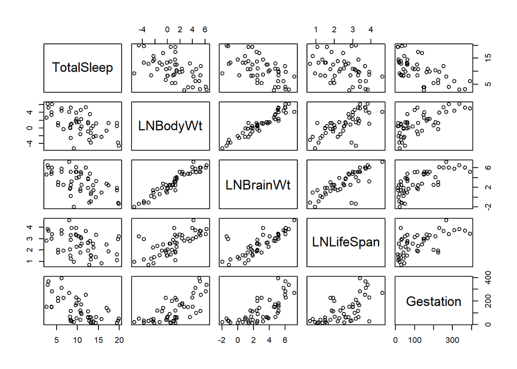

```r
animal_mat2 <- animals |> select(TotalSleep,
                                 LNBodyWt,
                                 LNBrainWt,
                                 LNLifeSpan,
                                 Gestation)

pairs(animal_mat2)
```

```r
animal_mat2 |> cor() |> round(2) |> kable()
```

|  | TotalSleep | LNBodyWt | LNBrainWt | LNLifeSpan | Gestation |
| --- | --- | --- | --- | --- | --- |
| TotalSleep | 1.00 | -0.56 | -0.57 | -0.37 | -0.62 |
| LNBodyWt | -0.56 | 1.00 | 0.95 | 0.71 | 0.71 |
| LNBrainWt | -0.57 | 0.95 | 1.00 | 0.79 | 0.73 |
| LNLifeSpan | -0.37 | 0.71 | 0.79 | 1.00 | 0.62 |
| Gestation | -0.62 | 0.71 | 0.73 | 0.62 | 1.00 |

The correlation matrix shows the numerical values of the correlations we see in the scatterplot.

### Scatterplot Matrix of Ordinal Variables

#### Lecture 14 In-class Exercises

#### **Question 4 (L14) - Session ID: bua345s23**

Which two ordinal categorical predictor variables appear to be multicollinear, i.e., highly correlated?

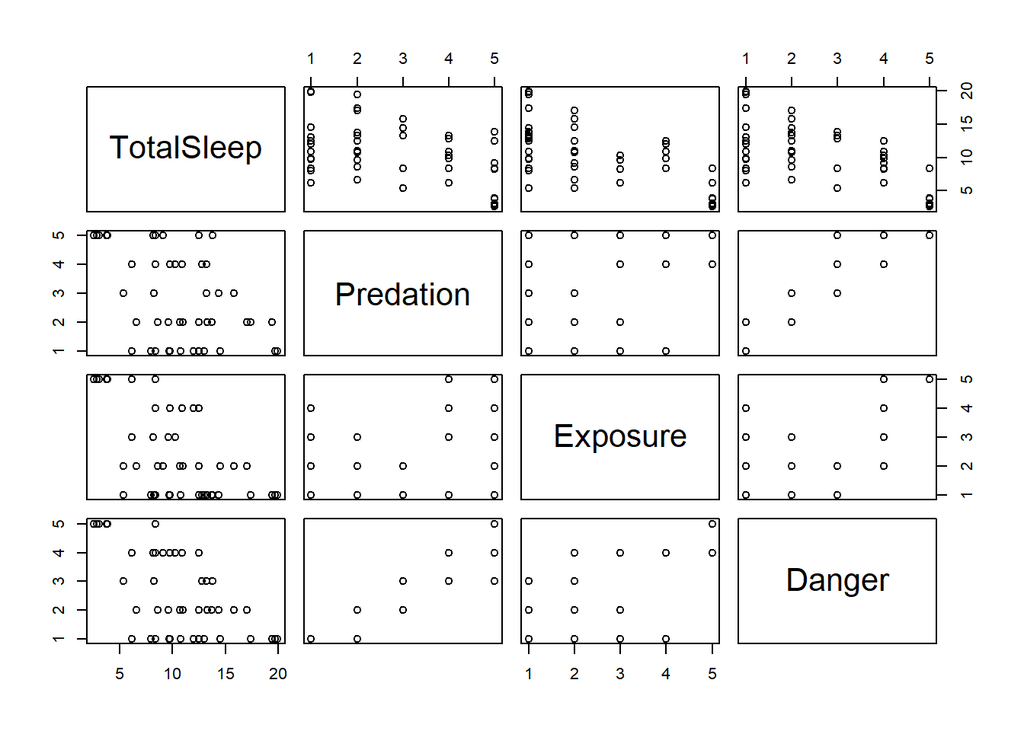

```r
animal_mat3 <- animals |> select(TotalSleep,
                                 Predation,
                                 Exposure,
                                 Danger)

pairs(animal_mat3)
```

```r
animal_mat3 |> cor() |> round(2)
```

```
##            TotalSleep Predation Exposure Danger
## TotalSleep       1.00     -0.48    -0.63  -0.63
## Predation       -0.48      1.00     0.66   0.95
## Exposure        -0.63      0.66     1.00   0.78
## Danger          -0.63      0.95     0.78   1.00
```

### Backward Elimination

**`1.`** Data examination and transformations completed

**`2.`** Create a full ‘saturated’ model with all potential predictor variables and interaction terms (This is subjective).

```r
 # convert ordinal variables to factors
animals <- animals |>
  mutate(PredF = factor(Predation),
         ExposF = factor(Exposure),
         DangrF=factor(Danger))

# full model (subjective)
animals_full <- lm(TotalSleep ~ LNBodyWt + LNBrainWt +
                     LNLifeSpan + Gestation +
                     PredF + ExposF + DangrF +
                     LNBodyWt*Gestation + LNLifeSpan*PredF +
                     LNLifeSpan*ExposF + LNLifeSpan*DangrF, data=animals)
```

### Backward Elimination

**`3.`** Use ‘Backward Elimination’ to pare full model down to a preliminary model.

- We cast a *wide net* to start by specifying that erms will remain in model if p-value < 0.1.
- Note that each category of each factor variable is shown making model look more complex than it is.

```r
(animals_BE <- ols_step_backward_p(animals_full, prem = 0.1, progress = T))
```

```
## Backward Elimination Method
## ---------------------------
##
## Candidate Terms:
##
## 1 . LNBodyWt
## 2 . LNBrainWt
## 3 . LNLifeSpan
## 4 . Gestation
## 5 . PredF
## 6 . ExposF
## 7 . DangrF
## 8 . LNBodyWt:Gestation
## 9 . LNLifeSpan:PredF
## 10 . LNLifeSpan:ExposF
## 11 . LNLifeSpan:DangrF
##
## We are eliminating variables based on p value...
##
## Variables Removed:
```

```
## Note: model has aliased coefficients
##       sums of squares computed by model comparison
```

```
## - LNLifeSpan:DangrF
## - LNBrainWt
## - LNLifeSpan:ExposF
## - LNBodyWt:Gestation
## - ExposF
##
## No more variables satisfy the condition of p value = 0.1
##
##
## Final Model Output
## ------------------
##
##                         Model Summary
## --------------------------------------------------------------
## R                       0.923       RMSE                2.124
## R-Squared               0.851       Coef. Var          19.991
## Adj. R-Squared          0.783       MSE                 4.511
## Pred R-Squared          0.660       MAE                 1.283
## --------------------------------------------------------------
##  RMSE: Root Mean Square Error
##  MSE: Mean Square Error
##  MAE: Mean Absolute Error
##
##                                ANOVA
## -------------------------------------------------------------------
##                Sum of
##               Squares        DF    Mean Square      F         Sig.
## -------------------------------------------------------------------
## Regression    851.000        15         56.733    12.576    0.0000
## Residual      148.871        33          4.511
## Total         999.871        48
## -------------------------------------------------------------------
##
##                                       Parameter Estimates
## ------------------------------------------------------------------------------------------------
##             model       Beta    Std. Error    Std. Beta      t        Sig       lower     upper
## ------------------------------------------------------------------------------------------------
##       (Intercept)      6.324         2.635                  2.401    0.022      0.964    11.684
##          LNBodyWt     -0.813         0.202       -0.515    -4.027    0.000     -1.224    -0.402
##        LNLifeSpan      3.009         0.909        0.622     3.311    0.002      1.160     4.858
##         Gestation     -0.019         0.005       -0.424    -3.736    0.001     -0.029    -0.009
##            PredF2     14.639         3.291        1.431     4.448    0.000      7.944    21.335
##            PredF3     17.053         5.383        1.237     3.168    0.003      6.101    28.005
##            PredF4     11.414         4.830        0.884     2.363    0.024      1.587    21.241
##            PredF5      0.722         6.052        0.067     0.119    0.906    -11.592    13.035
##           DangrF2     -6.810         1.746       -0.648    -3.900    0.000    -10.363    -3.258
##           DangrF3     -8.701         3.444       -0.674    -2.527    0.016    -15.708    -1.695
##           DangrF4     -7.957         4.344       -0.651    -1.832    0.076    -16.794     0.881
##           DangrF5    -16.325         4.456       -1.265    -3.664    0.001    -25.390    -7.259
## LNLifeSpan:PredF2     -3.334         1.299       -0.794    -2.567    0.015     -5.976    -0.692
## LNLifeSpan:PredF3     -5.444         3.940       -0.615    -1.382    0.176    -13.459     2.571
## LNLifeSpan:PredF4     -1.160         1.537       -0.253    -0.755    0.456     -4.286     1.967
## LNLifeSpan:PredF5      3.357         1.868        0.887     1.797    0.081     -0.443     7.157
## ------------------------------------------------------------------------------------------------
```

```
##
##
##                                 Elimination Summary
## -----------------------------------------------------------------------------------
##         Variable                            Adj.
## Step         Removed          R-Square    R-Square     C(p)        AIC        RMSE
## -----------------------------------------------------------------------------------
##    1    LNLifeSpan:DangrF       0.8895      0.7695    -6.8275    232.8819    2.1914
##    2    LNBrainWt               0.8886      0.7773    -8.6644    231.2764    2.1539
##    3    LNLifeSpan:ExposF       0.8739      0.7838    -7.9733    229.3663    2.1220
##    4    LNBodyWt:Gestation      0.8739      0.7913    -9.9732    227.3665    2.0851
##    5    ExposF                  0.8511      0.7834    -7.8112    227.5076    2.1240
## -----------------------------------------------------------------------------------
```

### Backward Elimination - Next Steps

**`4.`** Examine predictors in preliminary model to confirm they are not too highly correlated with each other.

- If correlation for two variables, $R_{XY} \geq 0.8$, then one variable should be excluded.
- Variables in preliminary model: : `LNBodyWt`, `LNLifeSpan`, `Gestation`, `PredF`, `DangrF`, `LNLifeSpan*PredF`
  - Recall that `PredF` (Predation) and `DangrF` (Danger) are highly correlated.
  - `PredF` is included in an interaction term so exclude `DangrF`.

**`5.`** If model was modified in Step 4, rerun model through Backward Elimination (not always needed).

**`6.`** Interpret final model.

- Adjusted R<sup>2</sup> = 0.655
- Model below looks complicated, but each animal is in only one Predation Category.
- Baseline Predation Category = 1

```r
# specify final model
(animals_final <- ols_regress(TotalSleep ~ LNBodyWt + LNLifeSpan + Gestation +
                               PredF + LNLifeSpan*PredF, data=animals))
```

```
##                         Model Summary
## --------------------------------------------------------------
## R                       0.857       RMSE                2.680
## R-Squared               0.734       Coef. Var          25.223
## Adj. R-Squared          0.655       MSE                 7.181
## Pred R-Squared          0.547       MAE                 1.857
## --------------------------------------------------------------
##  RMSE: Root Mean Square Error
##  MSE: Mean Square Error
##  MAE: Mean Absolute Error
##
##                               ANOVA
## ------------------------------------------------------------------
##                Sum of
##               Squares        DF    Mean Square      F        Sig.
## ------------------------------------------------------------------
## Regression    734.163        11         66.742    9.294    0.0000
## Residual      265.708        37          7.181
## Total         999.871        48
## ------------------------------------------------------------------
##
##                                       Parameter Estimates
## -----------------------------------------------------------------------------------------------
##             model      Beta    Std. Error    Std. Beta      t        Sig       lower     upper
## -----------------------------------------------------------------------------------------------
##       (Intercept)     6.751         3.305                  2.043    0.048      0.054    13.448
##          LNBodyWt    -0.698         0.244       -0.442    -2.859    0.007     -1.192    -0.203
##        LNLifeSpan     2.855         1.133        0.591     2.519    0.016      0.559     5.151
##         Gestation    -0.020         0.006       -0.447    -3.285    0.002     -0.032    -0.008
##            PredF2    13.998         4.132        0.041     3.388    0.002      5.626    22.369
##            PredF3    11.883         5.514       -0.494     2.155    0.038      0.711    23.056
##            PredF4     2.654         4.102        0.021     0.647    0.522     -5.658    10.966
##            PredF5    -0.782         4.262       -0.316    -0.183    0.855     -9.418     7.855
## LNLifeSpan:PredF2    -5.367         1.478       -0.471    -3.632    0.001     -8.361    -2.373
## LNLifeSpan:PredF3    -7.390         3.141       -0.588    -2.352    0.024    -13.755    -1.025
## LNLifeSpan:PredF4    -0.941         1.356       -0.083    -0.694    0.492     -3.689     1.807
## LNLifeSpan:PredF5    -1.043         1.446       -0.091    -0.721    0.475     -3.973     1.887
## -----------------------------------------------------------------------------------------------
```

```r
# save coefficients
animals_model <- animals_final$model
```

### Using Model to Find Estimates - Exporting Model and Data to Excel

- This model can be used to find model estimates and residuals for all animals.
- We will **ALSO** do these calculations are done in an Excel Spreadsheet to clarify each model component in estimate.
- Below we export the data for three species to examine how the model works

```r
animals_model_data <- animals |>             # create new dataset with model variables only
  select(Species, TotalSleep, LNBodyWt, LNLifeSpan, Gestation, PredF)

(three_species <- animals_model_data |>       # create mini dataset with three species
  filter(Species %in% c("Baboon", "Donkey", "ArcticFox")) |>
  write_csv("ThreeSpecies.csv"))
```

```
## # A tibble: 3 × 6
##   Species   TotalSleep LNBodyWt LNLifeSpan Gestation PredF
##   <chr>          <dbl>    <dbl>      <dbl>     <dbl> <fct>
## 1 ArcticFox       12.5     1.22       2.64        60 1
## 2 Baboon           9.8     2.36       3.3        180 4
## 3 Donkey           3.1     5.23       3.69       365 5
```

### Using Model to Find Estimates - Exporting Model and Data to Excel

- Model coefficients for calculations can be extracted and exported to Excel.
- Below We create a two column dataset listing each model component and it’s beta coefficient.
- That dataset is exported as a .csv file for an in-class exercise.

```r
# examine and export model betas for worksheet
beta <- animals_final$betas
model_term <- names(beta)
(animal_betas <- tibble(model_term, beta) |>
    write_csv("animal_betas.csv"))
```

```
## # A tibble: 12 × 2
##    model_term           beta
##    <chr>               <dbl>
##  1 (Intercept)        6.75
##  2 LNBodyWt          -0.698
##  3 LNLifeSpan         2.85
##  4 Gestation         -0.0198
##  5 PredF2            14.0
##  6 PredF3            11.9
##  7 PredF4             2.65
##  8 PredF5            -0.782
##  9 LNLifeSpan:PredF2 -5.37
## 10 LNLifeSpan:PredF3 -7.39
## 11 LNLifeSpan:PredF4 -0.941
## 12 LNLifeSpan:PredF5 -1.04
```

### Lecture 14 In-class Exercises

#### **Question 5 (L14) - Session ID: bua345s23**

What is the regression estimate of total sleep for ‘Donkey’?

### Using Model to Find Estimates in R

- Model estimates can be calculated in R.
- The Excel Worksheet is used to demonstrate and clarify how those estimates are calculated.
- Students will be expected to calculate an estimate using a model with this level of complexity on Quiz 2.

```r
animals_model_data <- animals_model_data |>     # add model estimates to data
  mutate(Est_TotalSleep = lm(animals_model) |>
           predict(animals_model_data) |> round(2))

animals_model_data <- animals_model_data |>          # calculate residuals
  mutate(Resid = TotalSleep - Est_TotalSleep) |>
  relocate(Est_TotalSleep, Resid, .after=TotalSleep) # reorder variables

head(animals_model_data, 4) |> kable()               # print first 4 rows
```

| Species | TotalSleep | Est_TotalSleep | Resid | LNBodyWt | LNLifeSpan | Gestation | PredF |
| --- | --- | --- | --- | --- | --- | --- | --- |
| Africangiantpouchedrat | 8.3 | 11.00 | -2.70 | 0.00 | 1.50 | 42 | 3 |
| Americanopossum | 19.4 | 16.10 | 3.30 | 0.53 | 1.61 | 12 | 2 |
| ArcticFox | 12.5 | 12.25 | 0.25 | 1.22 | 2.64 | 60 | 1 |
| Baboon | 9.8 | 10.51 | -0.71 | 2.36 | 3.30 | 180 | 4 |

### Wine Data - Model Selection Example

*Can we determine what factors affect wine quality even if we KNOW NOTHING about wine cultivation and chemistry?*

**Maybe!**

- Since we have no prior knowledge, we start with a straightforward full model with all available predictors and no interactions.
  - In practice, a consultant would be working with a wine expert to carefully determine a saturated model that includes all possible interactions.

### Import Wine Data

- Notice that all variables are numeric (*`<dbl>`* stands for decimal value).

```r
wine <- read_csv("wine.csv", show_col_types = F) |>
  glimpse()
```

```
## Rows: 605
## Columns: 11
## $ Wine_Quality          <dbl> 5, 6, 7, 5, 7, 5, 5, 5, 5, 5, 5, 5, 6, 5, 5, 4, …
## $ Fixed_Acidity         <dbl> 9.3, 9.1, 7.9, 7.2, 11.9, 7.2, 7.4, 9.9, 7.8, 8.…
## $ Volatile_Acidity      <dbl> 0.48, 0.22, 0.34, 1.00, 0.43, 0.49, 0.67, 0.50, …
## $ Citric_Acidity        <dbl> 0.29, 0.24, 0.36, 0.00, 0.66, 0.24, 0.12, 0.50, …
## $ Residual_Sugar        <dbl> 2.1, 2.1, 1.9, 3.0, 3.1, 2.2, 1.6, 13.8, 1.9, 1.…
## $ Chlorides             <dbl> 0.127, 0.078, 0.065, 0.102, 0.109, 0.070, 0.186,…
## $ Free_Sulphur_Dioxide  <dbl> 6, 1, 5, 7, 10, 5, 5, 48, 27, 6, 7, 17, 29, 5, 1…
## $ Total_Sulphur_Dioxide <dbl> 16, 28, 10, 16, 23, 36, 21, 82, 55, 12, 50, 45, …
## $ Ph                    <dbl> 3.22, 3.41, 3.27, 3.43, 3.15, 3.33, 3.39, 3.16, …
## $ Sulfate               <dbl> 0.72, 0.87, 0.54, 0.46, 0.85, 0.48, 0.54, 0.75, …
## $ Alcohol               <dbl> 11.2, 10.3, 11.2, 10.0, 10.4, 9.4, 9.5, 8.8, 11.…
```

### Examine Correlation matrix for MultiCollinearity

```r
(cor_wine <- wine |> cor() |> round(2)) #  correlation matrix
```

```
##                       Wine_Quality Fixed_Acidity Volatile_Acidity
## Wine_Quality                  1.00          0.11            -0.39
## Fixed_Acidity                 0.11          1.00            -0.23
## Volatile_Acidity             -0.39         -0.23             1.00
## Citric_Acidity                0.22          0.68            -0.52
## Residual_Sugar                0.04          0.20            -0.01
## Chlorides                    -0.10          0.12             0.04
## Free_Sulphur_Dioxide          0.01         -0.18            -0.05
## Total_Sulphur_Dioxide        -0.08         -0.13             0.05
## Ph                           -0.06         -0.70             0.19
## Sulfate                       0.21          0.19            -0.24
## Alcohol                       0.45         -0.08            -0.17
##                       Citric_Acidity Residual_Sugar Chlorides
## Wine_Quality                    0.22           0.04     -0.10
## Fixed_Acidity                   0.68           0.20      0.12
## Volatile_Acidity               -0.52          -0.01      0.04
## Citric_Acidity                  1.00           0.16      0.21
## Residual_Sugar                  0.16           1.00      0.05
## Chlorides                       0.21           0.05      1.00
## Free_Sulphur_Dioxide           -0.07           0.18     -0.04
## Total_Sulphur_Dioxide           0.06           0.18      0.00
## Ph                             -0.55          -0.14     -0.26
## Sulfate                         0.27          -0.01      0.35
## Alcohol                         0.10           0.07     -0.21
##                       Free_Sulphur_Dioxide Total_Sulphur_Dioxide    Ph Sulfate
## Wine_Quality                          0.01                 -0.08 -0.06    0.21
## Fixed_Acidity                        -0.18                 -0.13 -0.70    0.19
## Volatile_Acidity                     -0.05                  0.05  0.19   -0.24
## Citric_Acidity                       -0.07                  0.06 -0.55    0.27
## Residual_Sugar                        0.18                  0.18 -0.14   -0.01
## Chlorides                            -0.04                  0.00 -0.26    0.35
## Free_Sulphur_Dioxide                  1.00                  0.65  0.08    0.00
## Total_Sulphur_Dioxide                 0.65                  1.00 -0.07    0.08
## Ph                                    0.08                 -0.07  1.00   -0.24
## Sulfate                               0.00                  0.08 -0.24    1.00
## Alcohol                              -0.03                 -0.08  0.21    0.05
##                       Alcohol
## Wine_Quality             0.45
## Fixed_Acidity           -0.08
## Volatile_Acidity        -0.17
## Citric_Acidity           0.10
## Residual_Sugar           0.07
## Chlorides               -0.21
## Free_Sulphur_Dioxide    -0.03
## Total_Sulphur_Dioxide   -0.08
## Ph                       0.21
## Sulfate                  0.05
## Alcohol                  1.00
```

```r
max(cor_wine[cor_wine < 1])
```

```
## [1] 0.68
```

### Model Selection

- We specify a full model using an esy shortcut:
  - If all variables are included, you can use `.` instead of listing them all.
- The we do three model selection procedures:
  - Backward Elimination (BE)
  - Forward Selection (FS)
  - Stepwise Selection (SS)

```r
wine_full <- lm(Wine_Quality ~ ., data = wine)                 # specify full model

wine_BE <- ols_step_backward_p(wine_full, progress=F)          # backward elimination

wine_FS <- ols_step_forward_p(wine_full, progress=F)           # forward selection

wine_SS <- ols_step_both_p(wine_full, progress=F)              # stepwise selection
```

#### Comparing Model Results

- Look at the LAST step for each method to determine which method results in the best fit.
- Comparison Measures:
  - **Adj. R<sup>2</sup>:** Higher value indicates better model fit
  - **C(p):** Lower value indicates better model fit (Also referred to as Mallow’s C(p)).
  - **AIC:** Lower value indicates better model fit (Akaike Information Criteria).
  - **RMSE:** Lower value indicates better model fit (Root mean Square Error).
- By comparing these measures and accounting for our understanding of these procedures, we can determine that **TWO** of these methods arrived at the same model.

### Lecture 15 In-class Exercises

#### **Question 4 (L15) - Session ID: bua345s23**

Which two model selection methods arrived at the same model for the wine data?

#### Backwards Elimination

```
##
##
##                               Elimination Summary
## -------------------------------------------------------------------------------
##         Variable                        Adj.
## Step       Removed        R-Square    R-Square     C(p)        AIC        RMSE
## -------------------------------------------------------------------------------
##    1    Residual_Sugar      0.3318      0.3217    9.1492    1233.2028    0.6639
##    2    Fixed_Acidity       0.3315      0.3226    7.3871    1231.4450    0.6635
##    3    Citric_Acidity      0.3312      0.3233    5.7006    1229.7639    0.6631
## -------------------------------------------------------------------------------
```

#### Forward Selection

```
##
##                                    Selection Summary
## ----------------------------------------------------------------------------------------
##         Variable                               Adj.
## Step           Entered           R-Square    R-Square      C(p)         AIC        RMSE
## ----------------------------------------------------------------------------------------
##    1    Alcohol                    0.2022      0.2009    108.3814    1324.4468    0.7206
##    2    Volatile_Acidity           0.3032      0.3009     20.5402    1244.5203    0.6740
##    3    Sulfate                    0.3174      0.3140      9.9221    1234.0711    0.6676
##    4    Chlorides                  0.3210      0.3165      8.7252    1232.8759    0.6664
##    5    Ph                         0.3256      0.3199      6.7047    1230.8334    0.6648
##    6    Total_Sulphur_Dioxide      0.3281      0.3214      6.4128    1230.5168    0.6641
##    7    Free_Sulphur_Dioxide       0.3312      0.3233      5.7006    1229.7639    0.6631
## ----------------------------------------------------------------------------------------
```

#### Stepwise Selection

```
##
##                                   Stepwise Selection Summary
## -----------------------------------------------------------------------------------------------
##                              Added/                   Adj.
## Step        Variable        Removed     R-Square    R-Square      C(p)         AIC        RMSE
## -----------------------------------------------------------------------------------------------
##    1        Alcohol         addition       0.202       0.201    108.3810    1324.4468    0.7206
##    2    Volatile_Acidity    addition       0.303       0.301     20.5400    1244.5203    0.6740
##    3        Sulfate         addition       0.317       0.314      9.9220    1234.0711    0.6676
##    4       Chlorides        addition       0.321       0.317      8.7250    1232.8759    0.6664
##    5           Ph           addition       0.326       0.320      6.7050    1230.8334    0.6648
## -----------------------------------------------------------------------------------------------
```

### Model Validation

```r
# create final model dataset save model
wine_model_data <- wine |>
  select(!c("Residual_Sugar","Fixed_Acidity","Citric_Acidity"))

# create save final model
wine_model_final <- ols_regress(Wine_Quality ~ ., data=wine_model_data)
wine_model <- wine_model_final$model

# add final model estimates and residuals to dataset
wine_model_data <- wine_model_data |>
  mutate(Est_Wine_Quality = lm(wine_model) |> predict(wine_model_data) |> round(2))

# calculate correlation between observed and estimated wine quality
wine_model_data |> select(Wine_Quality, Est_Wine_Quality) |> cor() |> round(2)
```

```
##                  Wine_Quality Est_Wine_Quality
## Wine_Quality             1.00             0.58
## Est_Wine_Quality         0.58             1.00
```

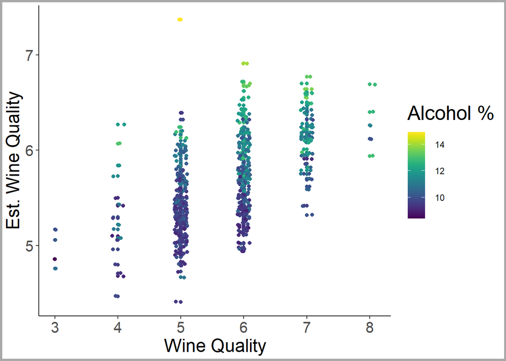

### **Key Points from Today**

- Regression modeling can be overwhelming
  - Automating part of the variable selection process is helpful.
  - Try different methods and compare results.
  - Results from automated processes are preliminary.
  - Model estimates and residuals can be added to dataset.
  - Demonstrated for both datasets and in HW 7.

*HAVE A GREAT BREAK!*

You may submit an ‘Engagement Question’ about each lecture until midnight on the day of the lecture. **A minimum of four submissions are required during the semester.**